# Camila_MaldonadoT2

Camila Maldonado

7 de julio de 2019

# **Trabajo Nº2: Análisis exploratorio de datos**

## Descripción de las variables

La variable de felcidad se considera como bienestar hedónico y es medida a traves de la escala de Felicidad de Lima (ebfl.m); esta mide el sentido positivo de la vida, la satisfacción con la vida, la realización personal y la alegría de vivir y se compone de 27 items. La variable de prosperidad se considera como bienestar eudaimónico y es medida a través de la Escala de Prosperidad (Flourishing Scale, fs.m) la cual está compuesta por 8 ítems que incluyen aspectos del funcionamiento humano como son las relaciones positivas, el sentimiento de competencia y el tener un propósito en la vida. Se responde en una escala de 1 (Fuertemente en desacuerdo) a 7 (Fuertemente de acuerdo); y los puntajes oscilan entre 8 y 56 puntos, donde los más altos indican mayor presencia de buen funcionamiento en las áreas cubiertas. Por otro lado la variable de bienestar social es medida a través de las Escalas de Bienestar Social, donde se evalúan 5 dimensiones del bienestar social: Integración social (ebs.1.m), Aceptación social (ebs.2.m), Contribución social (ebs.3.m), Actualización social (ebs.4.m) y Coherencia social (ebs.5.m). El instrumento está compuesto por 33 ítems y se responde utilizando una escala de 5 puntos, donde 1 es Muy en Desacuerdo y 5 es Muy de Acuerdo.

## Resumen de los datos

Para realizar un resumen rapido de los datos primero llamaremos las librerias que usaremos y la base de datos

```r
library(psych)
library(readxl)
library(tibble)
library(dplyr)
```

```r
library(ggplot2)
library(scales)
library(cluster)
library(car)
bienestar<- read_xlsx("salida_salud_sint.xlsx")
```

[output not shown]

```r
bienestar
```

| GENERO | EDAD | ECIVIL | CURSO | CARRERA | COMU | NIVELEDUC | TRABAJO | TRATPSIQ | ebfl.m | fs.m | ebs.1.m | ebs.2.m | ebs.3.m | ebs.4.m | ebs.5.m | ces.m | stais.m | audit |
| --- | --- | --- | --- | --- | --- | --- | --- | --- | --- | --- | --- | --- | --- | --- | --- | --- | --- | --- |
| 1 | NA | Soltero | 2 | 1 | 2 | NA | 4 | 2 | 3.53 | 4.08 | 3.96 | 2.86 | 4.79 | 3.57 | 4.00 | 0.47 | 1.02 | 0.43 |
| 2 | NA | NA | 4;5;6 | 1 | 1 | NA | 6 | 2 | 4.22 | 4.83 | 4.76 | 4.31 | 4.15 | 4.57 | 4.53 | 0.18 | 0.19 | 0.57 |
| NA | 21 | Soltero | 3 | 1 | 8 | 4 | 3 | 2 | 2.24 | 3.22 | 3.03 | 2.67 | 3.22 | 2.69 | 3.02 | 1.74 | 2.60 | 0.76 |
| 2 | 22 | Soltero | 2 | 1 | 4 | 6 | NA | 2 | 3.57 | 4.59 | 4.39 | 2.96 | 4.25 | 3.44 | 3.86 | 0.26 | 0.42 | 0.52 |
| 2 | 21 | Soltero | 3 | NA | 8 | 4 | 3 | 2 | 4.11 | 4.74 | 3.83 | 1.57 | 4.99 | 3.55 | 4.80 | 0.87 | 1.35 | 0.30 |
| 2 | 22 | NA | 3 | 1 | 1 | 5 | 4 | 2 | 3.44 | 3.27 | 4.32 | 4.96 | 5.00 | 4.04 | 4.89 | 1.43 | 2.41 | 0.11 |
| 2 | NA | Soltero | NA | 1 | 1 | 6 | 5 | 2 | 3.64 | 4.43 | 4.64 | 2.87 | 4.83 | 3.71 | 4.21 | 0.99 | 1.21 | 0.19 |
| 2 | 21 | Soltero | 4;5;6 | 1 | NA | 4 | 4 | 2 | 3.60 | 4.46 | 4.02 | 2.39 | 3.64 | 2.34 | 4.19 | 2.36 | 0.69 | 0.98 |
| 2 | NA | Soltero | 3 | NA | 8 | NA | 2 | 2 | 3.57 | 4.09 | 4.16 | 3.26 | 4.78 | 4.87 | 5.00 | 0.29 | 0.51 | 0.40 |
| 1 | NA | Soltero | 2 | 1 | NA | 4 | 3 | 2 | 2.47 | 3.09 | 2.85 | 1.61 | 3.01 | 2.39 | 3.55 | 0.82 | 1.20 | 1.82 |

[output cut: 507 more lines]

## Análisis descriptivo de género y comuna

Luego veremos parámetros descriptivos de las variables de género, comuna y las variables de prosperidad y bienestar social. Primero veremos el % de hombres y mujeres y el % por comuna. Es posible crear una variablde de tipo factor que muestre a que número corresponde cada sexo.

```r
sexo<-factor(bienestar$GENERO, labels = c("H", "M"))
table(sexo)
```

```
## sexo
##   H   M
## 166 340
```

Podemos ver que hay 166 hombres y 340 mujeres. Ahora realizaremos lo mismo para las comunas

```r
comuna<- factor(bienestar$COMU, labels = c("Concepcion", "Talcahuano", "San pedro", "Hualpén", "Chiguayante", "Coronel", "Lota", "Otra"))
table(comuna)
```

```
## comuna
##  Concepcion  Talcahuano   San pedro     Hualpén Chiguayante     Coronel
##         197          36          55          23          29          10
##        Lota        Otra
##           6          42
```

Crearemos un data frame que agrupe las tres variables a usar para este analisis

```r
bienestarsocial<- data.frame(
  Integracion= bienestar$ebs.1.m,
  Aceptacion= bienestar$ebs.2.m,
  Contribucion= bienestar$ebs.3.m,
  Actualizacion= bienestar$ebs.4.m,
  Coherencia= bienestar$ebs.5.m)
bi<- data.frame(
  Felicidad= bienestar$ebfl.m,
  Prosperidad=bienestar$fs.m,
  Bienestarsocial=bienestarsocial)
```

## Variables en relacion a comuna

```r
describeBy(bi,comuna)
```

```
##
##  Descriptive statistics by group
## group: Concepcion
##                               vars   n mean   sd median trimmed  mad  min
## Felicidad                        1 197 3.81 0.69   3.89    3.86 0.65 1.05
## Prosperidad                      2 197 4.07 0.61   4.19    4.12 0.59 1.00
## Bienestarsocial.Integracion      3 197 3.77 0.65   3.85    3.80 0.58 1.92
## Bienestarsocial.Aceptacion       4 197 3.09 0.77   3.07    3.10 0.80 1.06
## Bienestarsocial.Contribucion     5 197 4.06 0.66   4.13    4.11 0.76 2.27
## Bienestarsocial.Actualizacion    6 197 3.65 0.66   3.68    3.66 0.65 1.42
## Bienestarsocial.Coherencia       7 197 3.82 0.72   3.85    3.85 0.62 1.46
##                               max range  skew kurtosis   se
## Felicidad                       5  3.95 -0.85     1.04 0.05
## Prosperidad                     5  4.00 -1.07     2.56 0.04
## Bienestarsocial.Integracion     5  3.08 -0.51     0.00 0.05
## Bienestarsocial.Aceptacion      5  3.94 -0.04    -0.28 0.06
## Bienestarsocial.Contribucion    5  2.73 -0.49    -0.52 0.05
## Bienestarsocial.Actualizacion   5  3.58 -0.33     0.04 0.05
## Bienestarsocial.Coherencia      5  3.54 -0.59     0.58 0.05
## --------------------------------------------------------
## group: Talcahuano
##                               vars  n mean   sd median trimmed  mad  min
## Felicidad                        1 36 3.80 0.63   3.84    3.82 0.66 2.05
## Prosperidad                      2 36 4.11 0.51   4.13    4.13 0.48 2.81
## Bienestarsocial.Integracion      3 36 3.81 0.50   3.81    3.81 0.39 2.63
## Bienestarsocial.Aceptacion       4 36 2.98 0.70   2.93    2.99 0.64 1.57
## Bienestarsocial.Contribucion     5 36 4.27 0.57   4.34    4.31 0.60 2.78
## Bienestarsocial.Actualizacion    6 36 3.40 0.72   3.51    3.45 0.76 1.46
## Bienestarsocial.Coherencia       7 36 3.90 0.74   3.98    3.94 0.55 1.72
##                                max range  skew kurtosis   se
## Felicidad                     5.00  2.95 -0.45    -0.07 0.11
## Prosperidad                   5.00  2.19 -0.40    -0.01 0.08
## Bienestarsocial.Integracion   4.89  2.26  0.03     0.00 0.08
## Bienestarsocial.Aceptacion    4.37  2.80 -0.06    -0.66 0.12
## Bienestarsocial.Contribucion  5.00  2.22 -0.72    -0.33 0.09
## Bienestarsocial.Actualizacion 4.56  3.10 -0.70    -0.01 0.12
## Bienestarsocial.Coherencia    5.00  3.28 -0.63     0.54 0.12
## --------------------------------------------------------
## group: San pedro
##                               vars  n mean   sd median trimmed  mad  min
```

[output cut: 90 more lines]

```
## Felicidad                        1 42 3.76 0.63   3.88    3.81 0.57 2.24
## Prosperidad                      2 42 4.11 0.49   4.13    4.14 0.33 2.98
## Bienestarsocial.Integracion      3 42 3.76 0.54   3.85    3.77 0.50 2.62
## Bienestarsocial.Aceptacion       4 42 2.92 0.76   3.02    2.95 0.76 1.32
## Bienestarsocial.Contribucion     5 42 4.31 0.54   4.36    4.36 0.56 2.88
## Bienestarsocial.Actualizacion    6 42 3.47 0.60   3.49    3.49 0.53 1.31
## Bienestarsocial.Coherencia       7 42 3.75 0.79   3.78    3.75 1.10 2.27
##                                max range  skew kurtosis   se
## Felicidad                     4.76  2.52 -0.54    -0.39 0.10
## Prosperidad                   5.00  2.02 -0.43    -0.19 0.08
## Bienestarsocial.Integracion   4.79  2.17 -0.29    -0.56 0.08
## Bienestarsocial.Aceptacion    4.17  2.85 -0.33    -0.77 0.12
## Bienestarsocial.Contribucion  5.00  2.12 -0.74    -0.18 0.08
## Bienestarsocial.Actualizacion 4.87  3.56 -0.80     2.24 0.09
## Bienestarsocial.Coherencia    5.00  2.73 -0.05    -1.16 0.12
```

Se aprecia que las medias mas altas para todas las comunas estan en las variables de prosperidad y de contribucion social, y no se aprecia una diferencia grande en los niveles de las variables por comuna.

## Variables en relacion a sexo

Ahora veremos la relacion de estas variables con el sexo

```r
describeBy(bi,sexo)
```

```
##
##  Descriptive statistics by group
## group: H
##                               vars   n mean   sd median trimmed  mad  min
## Felicidad                        1 166 3.75 0.68   3.83    3.80 0.62 1.40
## Prosperidad                      2 166 4.06 0.58   4.10    4.11 0.52 1.46
## Bienestarsocial.Integracion      3 166 3.77 0.65   3.79    3.79 0.59 1.92
## Bienestarsocial.Aceptacion       4 166 3.03 0.74   3.06    3.03 0.73 1.32
## Bienestarsocial.Contribucion     5 166 4.07 0.68   4.12    4.12 0.74 1.81
## Bienestarsocial.Actualizacion    6 166 3.52 0.68   3.58    3.54 0.66 1.31
## Bienestarsocial.Coherencia       7 166 3.88 0.77   3.91    3.92 0.79 1.43
##                               max range  skew kurtosis   se
## Felicidad                       5  3.60 -0.79     0.61 0.05
## Prosperidad                     5  3.54 -1.04     2.20 0.05
## Bienestarsocial.Integracion     5  3.08 -0.35    -0.01 0.05
## Bienestarsocial.Aceptacion      5  3.68 -0.01    -0.17 0.06
## Bienestarsocial.Contribucion    5  3.19 -0.54    -0.19 0.05
## Bienestarsocial.Actualizacion   5  3.69 -0.38     0.36 0.05
## Bienestarsocial.Coherencia      5  3.57 -0.53     0.05 0.06
## --------------------------------------------------------
## group: M
##                               vars   n mean   sd median trimmed  mad  min
## Felicidad                        1 340 3.83 0.66   3.91    3.88 0.67 1.05
## Prosperidad                      2 340 4.14 0.54   4.22    4.18 0.49 1.00
## Bienestarsocial.Integracion      3 340 3.85 0.56   3.88    3.87 0.49 2.01
## Bienestarsocial.Aceptacion       4 340 3.11 0.72   3.05    3.12 0.76 1.06
## Bienestarsocial.Contribucion     5 340 4.15 0.61   4.19    4.20 0.67 1.82
## Bienestarsocial.Actualizacion    6 340 3.62 0.61   3.64    3.64 0.64 1.46
## Bienestarsocial.Coherencia       7 340 3.79 0.71   3.84    3.83 0.62 1.46
##                                max range  skew kurtosis   se
## Felicidad                     5.00  3.95 -0.66     0.37 0.04
## Prosperidad                   5.00  4.00 -0.96     2.58 0.03
## Bienestarsocial.Integracion   5.00  2.99 -0.38     0.06 0.03
## Bienestarsocial.Aceptacion    4.96  3.90 -0.09    -0.22 0.04
## Bienestarsocial.Contribucion  5.00  3.18 -0.67     0.20 0.03
## Bienestarsocial.Actualizacion 5.00  3.54 -0.29     0.05 0.03
## Bienestarsocial.Coherencia    5.00  3.54 -0.58     0.44 0.04
```

A partir del analisis descriptivo vemos que en las mujeres tienen mayor media en sus puntajes de Prosperidad y Contribucion social, lo cual ocurre de manera similar con los hombres quienes tambien tienen sus dos promedios mas altos en estas dos variables, y su promedio mas bajo en aceptacion social.

## Analisis univariados

### Felicidad

Realizaremos ahora histogramas de cada variable. Primero realizaremos un analisis de la variable de felicidad

```r
describe(bienestar$ebfl.m)
```

```
##    vars   n mean   sd median trimmed  mad  min max range  skew kurtosis
## X1    1 517  3.8 0.67   3.88    3.85 0.65 1.05   5  3.95 -0.71     0.48
##      se
## X1 0.03
```

```r
var(bienestar$ebfl.m)
```

```
## [1] 0.4422982
```

La variable de felicidad presenta una media de 3.8 y una varianza de 0.44

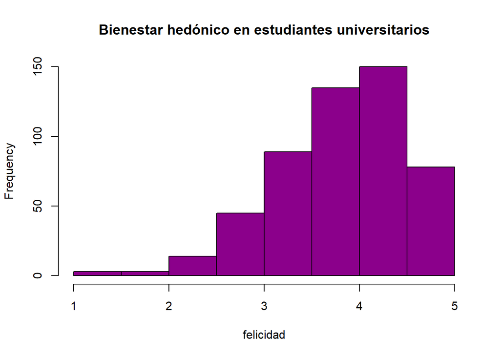

```r
hist(bienestar$ebfl.m, main = "Bienestar hedónico en estudiantes universitarios", xlab = "felicidad", col = "darkmagenta")
```

### Prosperidad

Ahora veremos la variable de prosperidad. Realizaremos un histograma y analisis descriptivo

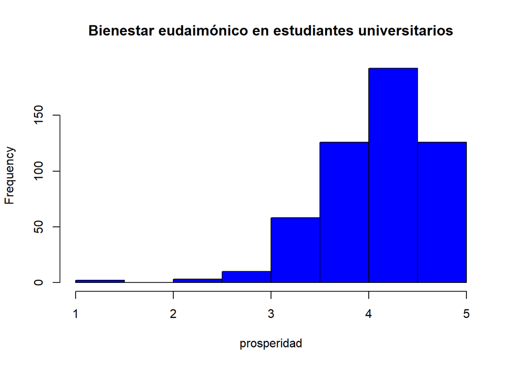

```r
hist(bienestar$fs.m, main = "Bienestar eudaimónico en estudiantes universitarios", xlab = "prosperidad", col = "blue")
```

```r
describe(bienestar$fs.m)
```

```
##    vars   n mean   sd median trimmed  mad min max range  skew kurtosis
## X1    1 517 4.11 0.55   4.18    4.15 0.52   1   5     4 -0.98     2.43
##      se
## X1 0.02
```

```r
var(bienestar$fs.m)
```

```
## [1] 0.3060001
```

La media general para esta variable es de 4.11, donde el minmo es 1 y el maximo 5, y la varianza es de 0.30

### Bienestar social

Luego para la variable de bienestar social

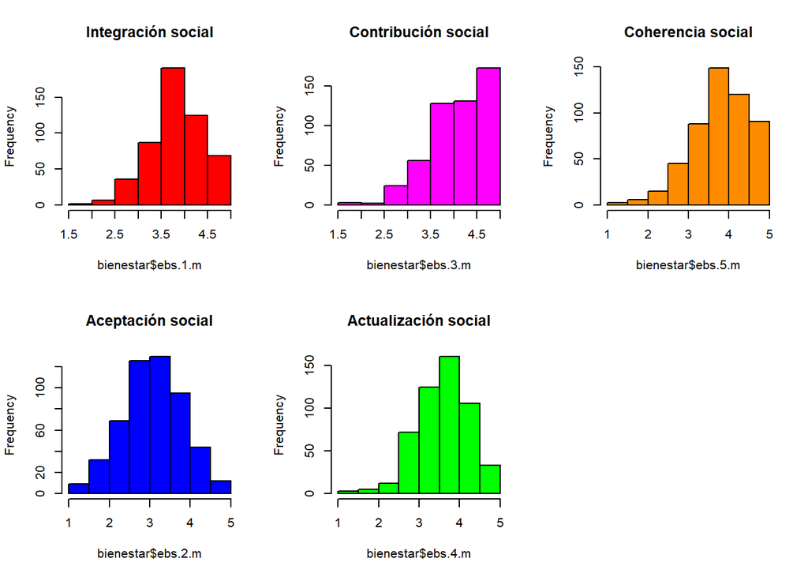

```r
par(mfcol = c(2, 3))
hist(bienestar$ebs.1.m, main = "Integración social", col = "red" )
hist(bienestar$ebs.2.m, main = "Aceptación social", col = "blue" )
hist(bienestar$ebs.3.m, main = "Contribución social", col = "magenta" )
hist(bienestar$ebs.4.m, main = "Actualización social", col = "green" )
hist(bienestar$ebs.5.m, main = "Coherencia social", col = "darkorange" )
```

Creamos un data frame que incluya las 5 dimensiones de bienestar social para realizar analisis descriptivo de la variable

```r
describe(bienestarsocial)
```

|  | vars | n | mean | sd | median | trimmed | mad | min | max | range | skew | kurtosis | se |
| --- | --- | --- | --- | --- | --- | --- | --- | --- | --- | --- | --- | --- | --- |
| Integracion | 1 | 517 | 3.821760 | 0.5913699 | 3.84 | 3.843639 | 0.548562 | 1.92 | 5 | 3.08 | -0.38441079 | 0.12102767 | 0.02600842 |
| Aceptacion | 2 | 517 | 3.085977 | 0.7324034 | 3.06 | 3.094458 | 0.741300 | 1.06 | 5 | 3.94 | -0.07089499 | -0.23412600 | 0.03221107 |
| Contribucion | 3 | 517 | 4.124603 | 0.6334305 | 4.17 | 4.173422 | 0.711648 | 1.81 | 5 | 3.19 | -0.64731814 | 0.09951079 | 0.02785824 |
| Actualizacion | 4 | 517 | 3.589884 | 0.6330390 | 3.61 | 3.605639 | 0.652344 | 1.31 | 5 | 3.69 | -0.34723398 | 0.28181142 | 0.02784102 |
| Coherencia | 5 | 517 | 3.822244 | 0.7295727 | 3.88 | 3.858024 | 0.652344 | 1.43 | 5 | 3.57 | -0.54126123 | 0.28435670 | 0.03208657 |

Luego de realizar un analsis descriptivo de la variable de bienestar social se aprecia que la dimension con mayor media es la de contribución social.

## Analisis entre variables

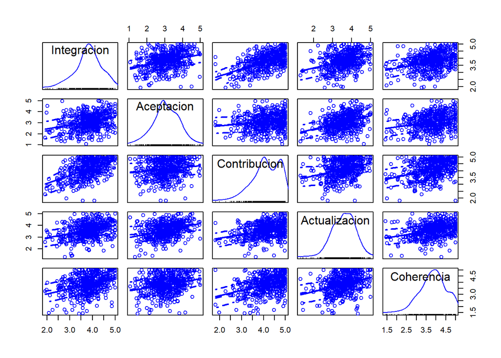

```r
scatterplotMatrix(bienestarsocial)
```

se ven relaciones lineales entre todos los componentes de bienestar social. Para ver las relaciones entre tipos de bienestar, usaremos el data frame creado con las 3 variables

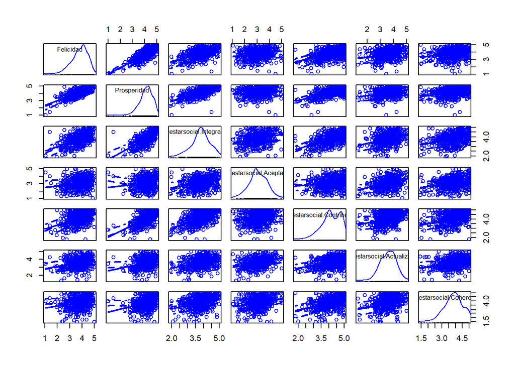

```r
scatterplotMatrix(bi)
```

A partir del grafico se ve que la relacion entre las variables son en su mayoria relaciones lineales y positivas, sin embargo a simple vista pareciera ser que la recta en la relacion de Aceptacion social con Prosperidad y con Felicidad, es mas paralela a el eje x, por lo que realizaremos un grafico para cada una de estas relaciones para distinguir mejor la recta

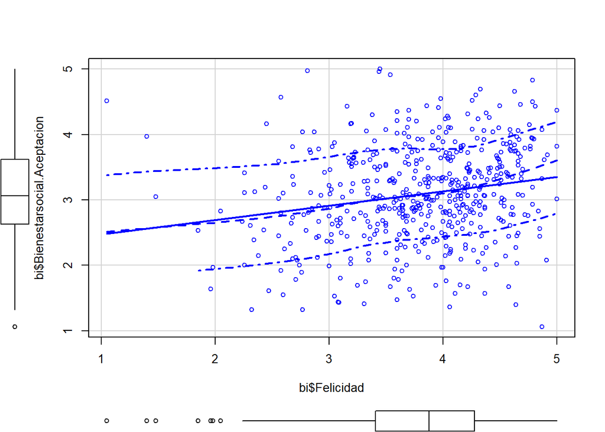

```r
scatterplot(bi$Felicidad, bi$Bienestarsocial.Aceptacion)
```

Se confirma relacion lineal entre Aceptación social y felicidad

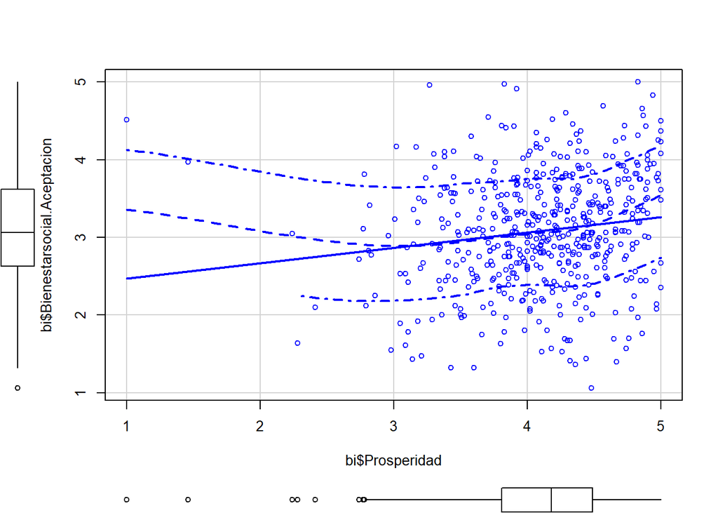

```r
scatterplot(bi$Prosperidad, bi$Bienestarsocial.Aceptacion)
```

## Analisis de conglomerados

Primero, usamos el data frame que incluye las tres variables para hacer una variable con la que se hará el analisis por conglomerado

[figure not shown]

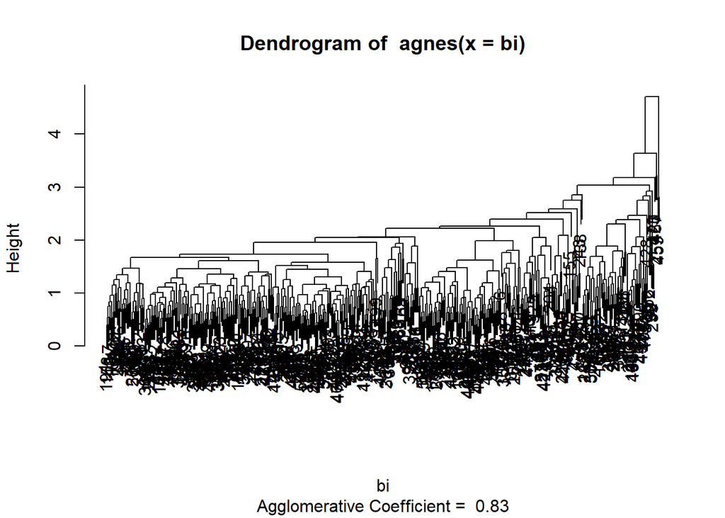

```r
acj<- agnes(bi)
plot(acj)
```

A traves del grafico, se decide cortar en el 2, por lo que quedarian un total de 15 grupos. Probamos una division de 15 grupos

```r
gr.15<-cutree(acj,15)
describeBy(bi, group=gr.15)
```

```
##
##  Descriptive statistics by group
## group: 1
##                               vars   n mean   sd median trimmed  mad  min
## Felicidad                        1 434 3.96 0.53   4.02    3.98 0.55 2.43
## Prosperidad                      2 434 4.24 0.43   4.24    4.25 0.46 3.02
## Bienestarsocial.Integracion      3 434 3.96 0.49   3.95    3.96 0.47 2.68
## Bienestarsocial.Aceptacion       4 434 3.19 0.66   3.17    3.19 0.67 1.06
## Bienestarsocial.Contribucion     5 434 4.26 0.52   4.26    4.30 0.59 2.68
## Bienestarsocial.Actualizacion    6 434 3.69 0.55   3.68    3.69 0.56 1.85
## Bienestarsocial.Coherencia       7 434 3.92 0.66   3.96    3.95 0.67 1.64
##                               max range  skew kurtosis   se
## Felicidad                       5  2.57 -0.34    -0.45 0.03
## Prosperidad                     5  1.98 -0.23    -0.49 0.02
## Bienestarsocial.Integracion     5  2.32  0.01    -0.27 0.02
## Bienestarsocial.Aceptacion      5  3.94  0.04    -0.04 0.03
## Bienestarsocial.Contribucion    5  2.32 -0.48    -0.38 0.03
## Bienestarsocial.Actualizacion   5  3.15 -0.07    -0.19 0.03
## Bienestarsocial.Coherencia      5  3.36 -0.34    -0.22 0.03
## --------------------------------------------------------
## group: 2
##                               vars  n mean   sd median trimmed  mad  min
## Felicidad                        1 58 3.01 0.64   2.91    3.00 0.67 1.48
## Prosperidad                      2 58 3.40 0.53   3.36    3.39 0.45 2.24
## Bienestarsocial.Integracion      3 58 3.01 0.49   3.03    2.99 0.50 1.92
## Bienestarsocial.Aceptacion       4 58 2.51 0.70   2.51    2.48 0.84 1.36
## Bienestarsocial.Contribucion     5 58 3.28 0.46   3.27    3.27 0.43 2.27
## Bienestarsocial.Actualizacion    6 58 2.91 0.58   2.88    2.91 0.42 1.42
## Bienestarsocial.Coherencia       7 58 3.31 0.51   3.38    3.34 0.62 2.06
##                                max range  skew kurtosis   se
## Felicidad                     4.65  3.17  0.14    -0.37 0.08
## Prosperidad                   4.66  2.42  0.24    -0.04 0.07
## Bienestarsocial.Integracion   4.26  2.34  0.23    -0.19 0.06
## Bienestarsocial.Aceptacion    4.04  2.68  0.27    -0.90 0.09
## Bienestarsocial.Contribucion  4.23  1.96  0.08    -0.54 0.06
## Bienestarsocial.Actualizacion 4.22  2.80 -0.05     0.28 0.08
## Bienestarsocial.Coherencia    4.18  2.12 -0.30    -0.74 0.07
## --------------------------------------------------------
## group: 3
##                               vars n mean   sd median trimmed  mad  min
```

[output cut: 216 more lines]

```
## Felicidad                        1 1 4.29 NA   4.29    4.29   0 4.29 4.29
## Prosperidad                      2 1 4.45 NA   4.45    4.45   0 4.45 4.45
## Bienestarsocial.Integracion      3 1 4.08 NA   4.08    4.08   0 4.08 4.08
## Bienestarsocial.Aceptacion       4 1 3.06 NA   3.06    3.06   0 3.06 3.06
## Bienestarsocial.Contribucion     5 1 1.81 NA   1.81    1.81   0 1.81 1.81
## Bienestarsocial.Actualizacion    6 1 4.19 NA   4.19    4.19   0 4.19 4.19
## Bienestarsocial.Coherencia       7 1 5.00 NA   5.00    5.00   0 5.00 5.00
##                               range skew kurtosis se
## Felicidad                         0   NA       NA NA
## Prosperidad                       0   NA       NA NA
## Bienestarsocial.Integracion       0   NA       NA NA
## Bienestarsocial.Aceptacion        0   NA       NA NA
## Bienestarsocial.Contribucion      0   NA       NA NA
## Bienestarsocial.Actualizacion     0   NA       NA NA
## Bienestarsocial.Coherencia        0   NA       NA NA
```

```r
gr.6<-cutree(acj,6)
describeBy(bi, group=gr.6)
```

```
##
##  Descriptive statistics by group
## group: 1
##                               vars   n mean   sd median trimmed  mad  min
## Felicidad                        1 445 3.93 0.55   4.00    3.96 0.56 1.98
## Prosperidad                      2 445 4.23 0.43   4.24    4.24 0.46 3.02
## Bienestarsocial.Integracion      3 445 3.95 0.49   3.94    3.95 0.47 2.68
## Bienestarsocial.Aceptacion       4 445 3.18 0.68   3.16    3.18 0.70 1.06
## Bienestarsocial.Contribucion     5 445 4.27 0.52   4.27    4.30 0.58 2.68
## Bienestarsocial.Actualizacion    6 445 3.69 0.56   3.70    3.69 0.55 1.85
## Bienestarsocial.Coherencia       7 445 3.93 0.66   3.97    3.96 0.67 1.64
##                               max range  skew kurtosis   se
## Felicidad                       5  3.02 -0.44    -0.23 0.03
## Prosperidad                     5  1.98 -0.21    -0.56 0.02
## Bienestarsocial.Integracion     5  2.32  0.02    -0.28 0.02
## Bienestarsocial.Aceptacion      5  3.94 -0.01    -0.07 0.03
## Bienestarsocial.Contribucion    5  2.32 -0.49    -0.38 0.02
## Bienestarsocial.Actualizacion   5  3.15 -0.06    -0.21 0.03
## Bienestarsocial.Coherencia      5  3.36 -0.35    -0.22 0.03
## --------------------------------------------------------
## group: 2
##                               vars  n mean   sd median trimmed  mad  min
## Felicidad                        1 67 2.99 0.63   2.89    2.98 0.65 1.48
## Prosperidad                      2 67 3.41 0.53   3.35    3.39 0.46 2.24
## Bienestarsocial.Integracion      3 67 2.99 0.50   3.03    2.98 0.56 1.92
## Bienestarsocial.Aceptacion       4 67 2.47 0.72   2.44    2.43 0.79 1.32
## Bienestarsocial.Contribucion     5 67 3.26 0.51   3.33    3.27 0.46 1.82
## Bienestarsocial.Actualizacion    6 67 2.93 0.66   2.87    2.92 0.46 1.31
## Bienestarsocial.Coherencia       7 67 3.14 0.71   3.27    3.20 0.68 1.43
##                                max range  skew kurtosis   se
## Felicidad                     4.65  3.17  0.23    -0.39 0.08
## Prosperidad                   4.66  2.42  0.29    -0.16 0.06
## Bienestarsocial.Integracion   4.26  2.34  0.19    -0.35 0.06
## Bienestarsocial.Aceptacion    4.16  2.84  0.39    -0.71 0.09
## Bienestarsocial.Contribucion  4.23  2.41 -0.43     0.10 0.06
## Bienestarsocial.Actualizacion 4.34  3.03  0.07     0.20 0.08
## Bienestarsocial.Coherencia    4.27  2.84 -0.68    -0.28 0.09
## --------------------------------------------------------
## group: 3
##                               vars n mean   sd median trimmed  mad  min
```

[output cut: 54 more lines]

```
## Felicidad                        1 1 4.29 NA   4.29    4.29   0 4.29 4.29
## Prosperidad                      2 1 4.45 NA   4.45    4.45   0 4.45 4.45
## Bienestarsocial.Integracion      3 1 4.08 NA   4.08    4.08   0 4.08 4.08
## Bienestarsocial.Aceptacion       4 1 3.06 NA   3.06    3.06   0 3.06 3.06
## Bienestarsocial.Contribucion     5 1 1.81 NA   1.81    1.81   0 1.81 1.81
## Bienestarsocial.Actualizacion    6 1 4.19 NA   4.19    4.19   0 4.19 4.19
## Bienestarsocial.Coherencia       7 1 5.00 NA   5.00    5.00   0 5.00 5.00
##                               range skew kurtosis se
## Felicidad                         0   NA       NA NA
## Prosperidad                       0   NA       NA NA
## Bienestarsocial.Integracion       0   NA       NA NA
## Bienestarsocial.Aceptacion        0   NA       NA NA
## Bienestarsocial.Contribucion      0   NA       NA NA
## Bienestarsocial.Actualizacion     0   NA       NA NA
## Bienestarsocial.Coherencia        0   NA       NA NA
```

Realizando un analisis de conglomerados con 6 grupos, tenemos al igual que en el anterior, los dos primeros grupos continenen la mayoria de los casos (99%). El resto de los grupos se componen de 1 o 2 casos, presentado niveles heterogeneos en cada variable y llegando a los extremos de 1 o 5 puntos en algunas de estas. Las ventajas de 15 grupos se asocian a que se permiten visualizar lso casos mas extremos con puntajes las heterogeneos. Sin embargo, probando con 6 grupos pudimos ver que algunos de estos casos se pueden juntar. Probemos con menos grupos

```r
gr.4<-cutree(acj,4)
describeBy(bi, group=gr.4)
```

```
##
##  Descriptive statistics by group
## group: 1
##                               vars   n mean   sd median trimmed  mad  min
## Felicidad                        1 513 3.81 0.65   3.88    3.85 0.65 1.48
## Prosperidad                      2 513 4.12 0.52   4.18    4.15 0.50 2.24
## Bienestarsocial.Integracion      3 513 3.83 0.59   3.84    3.85 0.53 1.92
## Bienestarsocial.Aceptacion       4 513 3.08 0.73   3.06    3.09 0.73 1.06
## Bienestarsocial.Contribucion     5 513 4.13 0.63   4.17    4.18 0.70 1.81
## Bienestarsocial.Actualizacion    6 513 3.59 0.63   3.62    3.61 0.65 1.31
## Bienestarsocial.Coherencia       7 513 3.83 0.72   3.88    3.86 0.65 1.43
##                               max range  skew kurtosis   se
## Felicidad                       5  3.52 -0.58    -0.06 0.03
## Prosperidad                     5  2.76 -0.56     0.12 0.02
## Bienestarsocial.Integracion     5  3.08 -0.36     0.07 0.03
## Bienestarsocial.Aceptacion      5  3.94 -0.06    -0.21 0.03
## Bienestarsocial.Contribucion    5  3.19 -0.66     0.15 0.03
## Bienestarsocial.Actualizacion   5  3.69 -0.30     0.18 0.03
## Bienestarsocial.Coherencia      5  3.57 -0.48     0.17 0.03
## --------------------------------------------------------
## group: 2
##                               vars n mean   sd median trimmed  mad  min
## Felicidad                        1 2 1.23 0.25   1.23    1.23 0.26 1.05
## Prosperidad                      2 2 1.23 0.33   1.23    1.23 0.34 1.00
## Bienestarsocial.Integracion      3 2 3.26 1.77   3.26    3.26 1.86 2.01
## Bienestarsocial.Aceptacion       4 2 4.24 0.38   4.24    4.24 0.40 3.97
## Bienestarsocial.Contribucion     5 2 3.08 0.30   3.08    3.08 0.31 2.87
## Bienestarsocial.Actualizacion    6 2 3.85 0.56   3.85    3.85 0.59 3.45
## Bienestarsocial.Coherencia       7 2 4.14 0.27   4.14    4.14 0.28 3.95
##                                max range skew kurtosis   se
## Felicidad                     1.40  0.35    0    -2.75 0.17
## Prosperidad                   1.46  0.46    0    -2.75 0.23
## Bienestarsocial.Integracion   4.52  2.51    0    -2.75 1.25
## Bienestarsocial.Aceptacion    4.51  0.54    0    -2.75 0.27
## Bienestarsocial.Contribucion  3.29  0.42    0    -2.75 0.21
## Bienestarsocial.Actualizacion 4.24  0.79    0    -2.75 0.40
## Bienestarsocial.Coherencia    4.33  0.38    0    -2.75 0.19
## --------------------------------------------------------
## group: 3
##                               vars n mean sd median trimmed mad  min  max
```

[output cut: 18 more lines]

```
## Felicidad                        1 1 5.00 NA   5.00    5.00   0 5.00 5.00
## Prosperidad                      2 1 4.82 NA   4.82    4.82   0 4.82 4.82
## Bienestarsocial.Integracion      3 1 3.58 NA   3.58    3.58   0 3.58 3.58
## Bienestarsocial.Aceptacion       4 1 3.82 NA   3.82    3.82   0 3.82 3.82
## Bienestarsocial.Contribucion     5 1 3.15 NA   3.15    3.15   0 3.15 3.15
## Bienestarsocial.Actualizacion    6 1 2.99 NA   2.99    2.99   0 2.99 2.99
## Bienestarsocial.Coherencia       7 1 1.46 NA   1.46    1.46   0 1.46 1.46
##                               range skew kurtosis se
## Felicidad                         0   NA       NA NA
## Prosperidad                       0   NA       NA NA
## Bienestarsocial.Integracion       0   NA       NA NA
## Bienestarsocial.Aceptacion        0   NA       NA NA
## Bienestarsocial.Contribucion      0   NA       NA NA
## Bienestarsocial.Actualizacion     0   NA       NA NA
## Bienestarsocial.Coherencia        0   NA       NA NA
```

Si probamos con 4 grupos vemos que se integran los casos del segundo grupo de la prueba anterior, dentro del grupo grande con 513 casos y el resto de los grupos aparecen con 1 o 2 casos.

### Conclusion analisis por conglomerados jerarquicos

Por lo tanto, nos quedaremos con 6 casos ya que propone un balance entre la presencia de grupos con muchos casos y puntajes homogeneos (y que a su vez se aprecien diferencias en cada grupo) y grupos que incluyan casos extremos.

## Analisis de componentes principales

Antes de realizar este analisis, veremos la correlacion entre las variables, indicando si podriamos resumir la informacion en una cantidad menor de variables

```r
cor(bi)
```

```
##                               Felicidad Prosperidad
## Felicidad                     1.0000000   0.7361956
## Prosperidad                   0.7361956   1.0000000
## Bienestarsocial.Integracion   0.5158302   0.6607587
## Bienestarsocial.Aceptacion    0.1983340   0.1496922
## Bienestarsocial.Contribucion  0.4451695   0.5735992
## Bienestarsocial.Actualizacion 0.2793837   0.2815025
## Bienestarsocial.Coherencia    0.2159969   0.2802105
##                               Bienestarsocial.Integracion
## Felicidad                                       0.5158302
## Prosperidad                                     0.6607587
## Bienestarsocial.Integracion                     1.0000000
## Bienestarsocial.Aceptacion                      0.2852838
## Bienestarsocial.Contribucion                    0.5354424
## Bienestarsocial.Actualizacion                   0.3296839
## Bienestarsocial.Coherencia                      0.3419375
##                               Bienestarsocial.Aceptacion
## Felicidad                                      0.1983340
## Prosperidad                                    0.1496922
## Bienestarsocial.Integracion                    0.2852838
## Bienestarsocial.Aceptacion                     1.0000000
## Bienestarsocial.Contribucion                   0.1516565
## Bienestarsocial.Actualizacion                  0.3482929
## Bienestarsocial.Coherencia                     0.2497621
##                               Bienestarsocial.Contribucion
## Felicidad                                        0.4451695
## Prosperidad                                      0.5735992
## Bienestarsocial.Integracion                      0.5354424
## Bienestarsocial.Aceptacion                       0.1516565
## Bienestarsocial.Contribucion                     1.0000000
## Bienestarsocial.Actualizacion                    0.3136534
## Bienestarsocial.Coherencia                       0.3724323
##                               Bienestarsocial.Actualizacion
## Felicidad                                         0.2793837
## Prosperidad                                       0.2815025
## Bienestarsocial.Integracion                       0.3296839
## Bienestarsocial.Aceptacion                        0.3482929
## Bienestarsocial.Contribucion                      0.3136534
## Bienestarsocial.Actualizacion                     1.0000000
## Bienestarsocial.Coherencia                        0.3228043
##                               Bienestarsocial.Coherencia
## Felicidad                                      0.2159969
## Prosperidad                                    0.2802105
## Bienestarsocial.Integracion                    0.3419375
## Bienestarsocial.Aceptacion                     0.2497621
## Bienestarsocial.Contribucion                   0.3724323
## Bienestarsocial.Actualizacion                  0.3228043
## Bienestarsocial.Coherencia                     1.0000000
```

```r
acp<- prcomp(bi, scale =TRUE)
summary(acp)
```

```
## Importance of components:
##                           PC1    PC2    PC3    PC4    PC5     PC6     PC7
## Standard deviation     1.8078 1.0695 0.8895 0.7973 0.7188 0.65436 0.46540
## Proportion of Variance 0.4669 0.1634 0.1130 0.0908 0.0738 0.06117 0.03094
## Cumulative Proportion  0.4669 0.6303 0.7433 0.8341 0.9079 0.96906 1.00000
```

Vemos que el primer componente, al ser debiles las correlaciones entre variables debiles solo explicaria el 47% de la varianza, y solo se llega al 95% de la varianza con 6 componentes. Ahora veremos la relacion entre las variables y los componentes

```r
acp$rotation
```

```
##                                     PC1        PC2         PC3         PC4
## Felicidad                     0.4196732 -0.3123934  0.31127073 -0.01771471
## Prosperidad                   0.4617897 -0.3568237  0.11264122  0.01669801
## Bienestarsocial.Integracion   0.4470202 -0.1033148  0.05418062  0.17860405
## Bienestarsocial.Aceptacion    0.2317595  0.6223109  0.51834848  0.46539841
## Bienestarsocial.Contribucion  0.4125510 -0.1422573 -0.32534651 -0.05792218
## Bienestarsocial.Actualizacion 0.3095789  0.4732424  0.07184059 -0.81403076
## Bienestarsocial.Coherencia    0.3017410  0.3646188 -0.71259412  0.29139530
##                                       PC5         PC6          PC7
## Felicidad                      0.51391549 -0.31083858 -0.518026783
## Prosperidad                    0.15280252  0.03212470  0.788720263
## Bienestarsocial.Integracion   -0.28973404  0.76400857 -0.294973079
## Bienestarsocial.Aceptacion    -0.13884696 -0.21201699  0.097499291
## Bienestarsocial.Contribucion  -0.65113167 -0.51384356 -0.111137427
## Bienestarsocial.Actualizacion  0.04846167  0.09667000  0.026490611
## Bienestarsocial.Coherencia     0.42778148  0.01751547  0.000300159
```

## Discusion de los resultados

En base a los resultados obtenidos del analisis descriptivo y exploratorio podemos ver que los niveles de estas 3 variables de salud mental (bienestar hedónico, bienestar eudaimónico y bienestar social) son homogeneos en las comunas de la región del biobio y tanto em hombres como mujeres. Estas tres variables aluden a actitudes y creencias que las perosnas tienen de si mismos (en base a las definiciones de las variables), sin embargo solo una de ellas (aceptacion social), alude a creencias y actitudes hacia otros, siendo esta la dimension y la variable con mas bajos niveles a nivel general y que a su vez estaria menos relacionada con el resto de las variables medidas.

## Reflexión

De manera personal considero que en primer lugar estos analisis permiten tener una vision general de la temática que se esta investigando y podria permitir generar nuevas hipótesis con respecto a las variables medidas. Me asalta la duda de si estos analisis son factibles de realizar con multiples y variadas bases de datos,o si se pueden realizar si estas son adaptadas para estos casos, para lo cual considero que es muy importante conocer bien los analisis que se realizaran y siempre con un propósito en mente que tenga un beneficio para los analisis posteriores. Por otro lado, en cuanto a los resultados obtenidos, considero que la medicion exclusiva de estas variables positivas de salud mental no permiten obtener un panorama muy amplio de la salud mental en general de la poblacion, ya que las personas tienen a sobreestimar si nivel de bienestar consigo mismos. Sin embargo, me hace sentido que los niveles mas bajos estudieran en aceptacion social, lo cual es algo que vale la pena considerar con otros estudios y mediciones de otras variables asociadas a la interaccion entre personas.